# t-toets voor een verwachting

De analyse gebeurt met behulp van R en RStudio. Een inleiding tot deze software vind je [hier](https://ufora.ugent.be/d2l/le/discovery/view/course/386505).

# 1 Doel

Met deze techniek kan je nagaan of een verwachting in een populatie verschillend is van een vooropgestelde waarde.

# 2 Voorbeeld

Onderzoekers meten de variabele jobtevredenheid ($X$) aan de hand van een vragenlijst. Deze variabele kan elke waarde aannemen van $0$ tot $100$.

Uit een recent grootschalig onderzoek is gebleken dat Belgen gemiddeld $58$ scoren. Je vraagt je af of leerkrachten in het lager onderwijs hoger scoren dan $58$.

Je verzamelt gegevens om een antwoord te kunnen formuleren. Daarvoor trek je een steekproef van $54$ leerkrachten in het lager onderwijs.

# 3 Data importeren

De data bij dit voorbeeld kan je met het onderstaande commando importeren in R.

```r
mijn_data <- read.csv("https://da.ugent.be/datasets/tevredenheidsstudie.csv")
```

Inspecteer de data met de functie `head()`.

```r
head(mijn_data)
```

```
  leeftijd geslacht jobtevr familietevr vrije.tijd.tevr gezond.tevr
1       85        M      55          50              50          66
2       56        M      55          72              52          62
3       18        M      59          50              49          57
4       51        V      69          64              54          67
5       60        M      48          62              58          51
6       31        M      65          60              50          58
```

Het object `mijn_data` bevat een dataframe met alle gegevens. In dit voorbeeld hebben we enkel de variabele jobtevredenheid nodig. Die kan je apart selecteren uit het dataframe en in een nieuw object stoppen.

```r
jobtevr <- mijn_data$jobtevr
```

# 4 Hypothesen

De hypothesen die bij deze toets horen zijn:

$$H_0: \mu_X = \mu_0 \text{, of in dit geval } \mu_X = 58$$
$$H_a: \mu_X > \mu_0 \text{, of in dit geval } \mu_X > 58$$

De verwachting van de jobtevredenheid onder $H_0$ kan je ook als een object in R opslaan.

```r
mu_0 <- 58
```

# 5 Data verkennen

Met de functie `summary()` kan je snel een overzicht van een variabele krijgen.

```r
summary(jobtevr)
```

```
   Min. 1st Qu.  Median    Mean 3rd Qu.    Max.
  48.00   56.00   59.00   60.57   64.75   74.00
```

Met de functie `mean()` is het eenvoudig om afzonderlijk het gemiddelde van de variabele jobtevredenheid in de steekproef van $54$ leerkrachten te berekenen.

```r
mean(jobtevr)
```

```
[1] 60.57407
```

Deze waarde is wat groter dan $58$. Met een statistische toets zal je nagaan of het geloofwaardig is dat deze afwijking louter aan toeval te wijten is.

Een visuele samenvatting van `jobtevr` kan je bekomen door een boxplot te tekenen.

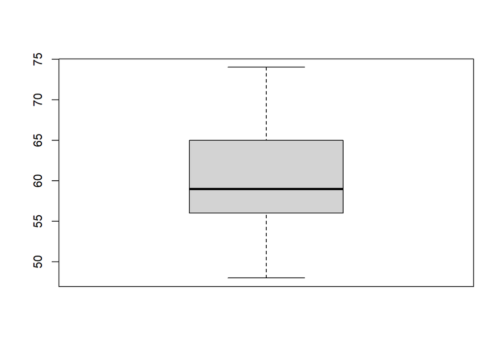

```r
boxplot(jobtevr)
```

# 6 Keuze toets

Je toetst of een verwachting $\mu_X$ groter is dan een gegeven waarde. De populatievariantie $\sigma_X^2$ is niet gekend. Je kiest dus voor een t-toets voor één verwachting.

## Assumpties

Om een t-toets voor één verwachting te kunnen gebruiken moet voldaan zijn aan volgende assumpties:

- $X$ moet tenminste van intervalniveau zijn. Dat is het geval in dit voorbeeld.
- $X$ moet een normale verdeling volgen of de steekproef moet voldoende groot zijn. Over de verdeling van de variabele is geen informatie gegeven, maar hier is de steekproefgrootte $n= 54$. De vuistregel is dat $n\geq30$ moet zijn, dus aan deze voorwaarde is voldaan.

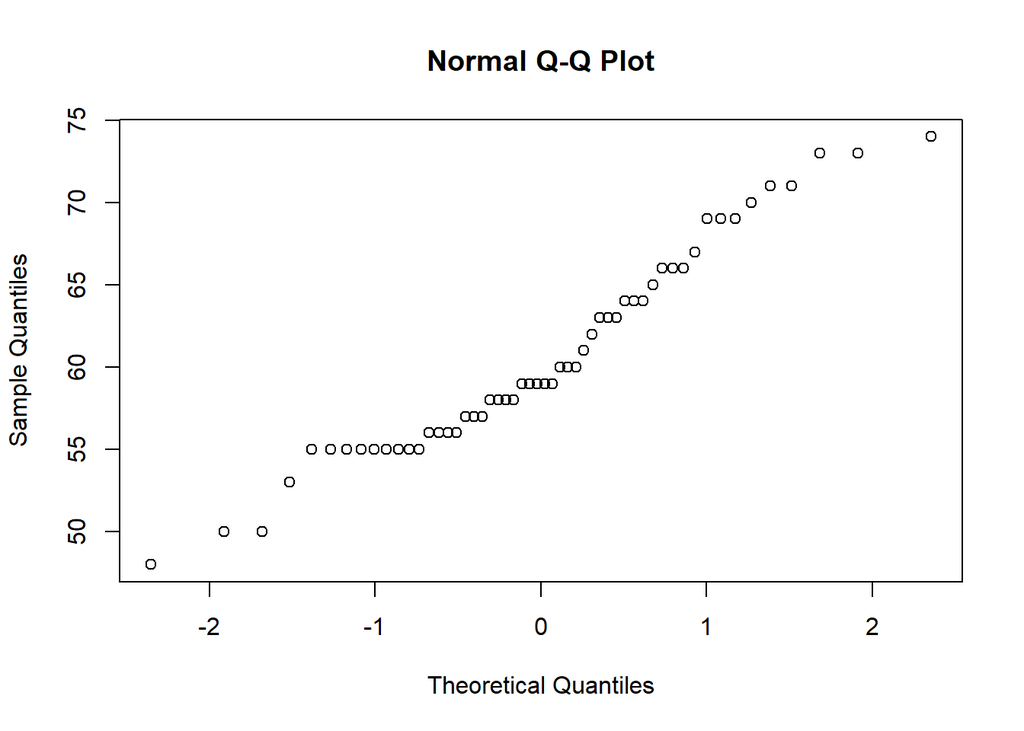

  ```r
  qqnorm(jobtevr)
  ```

# 7 Significantieniveau

Vóór je de toets uitvoert dien je een significantieniveau $\alpha$ te kiezen.

```r
alpha <- 0.10
```

# 8 Toets

De t-toets kan je uitvoeren met de functie `t.test()`:

```r
t.test(jobtevr, mu=mu_0, alternative="greater", conf.level=1-alpha)
```

```
    One Sample t-test

data:  jobtevr
t = 3.0099, df = 53, p-value = 0.001998
alternative hypothesis: true mean is greater than 58
90 percent confidence interval:
 59.46425      Inf
sample estimates:
mean of x
 60.57407
```

## Beslissing

Je stelt vast dat de overschrijdingskans $p= 0.0019977$ kleiner is dan de waarde voor $\alpha$ die eerder is vastgelegd, namelijk $\alpha=0.1$. Hieruit concludeer je dat je de nulhypothese moet verwerpen op het $10\%$ significantieniveau.

Je kan tot dezelfde conclusie komen aan de hand van het betrouwbaarheidsinterval. Je stelt vast dat de waarde $58$ zich niet in het $90\%$ betrouwbaarheidsinterval $[59.4642472, \infty{}[$ bevindt. De nulhypothese, die stelt dat er geen verschil is tussen beide groepen, is dus niet compatibel met de geobserveerde data. Je verwerpt bijgevolg de nulhypothese op het $10\%$ significantieniveau.

# 9 Conclusie

Je verwerpt de nulhypothese op het $10\%$ significantieniveau.